# Practicant amb training i test sets

Familiaritza't amb la programació científica mitjantçant la llibreria SKLearn / Scikitlearn.

- **Exercici 1**

Parteix el conjunt de `dadesDelayedFlights.csv` en train i test. Estudia els dos conjunts per separat, a nivell descriptiu.

- **Exercici 2**

Aplica algun procés de transformació (estandarditzar les dades numèriques, crear columnes dummies, polinomis...).

- **Exercici 3**

Resumeix les noves columnes generades de manera estadística i gràfica

```python
import pandas as pd
pd.set_option("display.max_columns", None)
from sklearn.model_selection import train_test_split
import numpy as np
import matplotlib.pyplot as plt
import seaborn as sns
from sklearn.preprocessing import StandardScaler, RobustScaler
from scipy import stats
```

# Data:

[Airlines Delay: Airline on-time statistics and delay causes](https://www.kaggle.com/giovamata/airlinedelaycauses)

```python
# Llegim el csv
df_raw = pd.read_csv("./archive/DelayedFlights.csv", index_col = [0])
```

#### Variable descriptions:

- Year: 1987-2008
- Month: 1-12
- DayofMonth: 1-31
- DayOfWeek: 1 (Monday) - 7 (Sunday)
- DepTime: departure time (local, hhmm)
- CRSDepTime: scheduled departure time (local, hhmm)
- ArrTime: arrival time (local, hhmm)
- CRSArrTime: scheduled arrival time (local, hhmm)
- UniqueCarrier: unique carrier code
- FlightNum: flight number
- TailNum: plane tail number
- ActualElapsedTime: flygth time in minutes (Total)
- CRSElapsedTime: scheduled flygth time in minutes (Total)
- AirTime: time on air in minutes
- ArrDelay: arrival delay in minutes
- DepDelay: departure delay in minutes
- Origin: origin IATA airport code
- Dest: destination IATA airport code
- Distance: distance in miles
- TaxiIn: taxi in time, in minutes (movement on ground)
- TaxiOut: taxi out time, in minutes (movement on ground)
- Cancelled: was the flight cancelled?
- CancellationCode: [reason for cancellation](https://aspmhelp.faa.gov/index/Types_of_Delay.html) (A = carrier, B = weather, C = NAS, D = security)
- Diverted: 1 = yes, 0 = no ("Desviado")
- CarrierDelay: delayed time due to Carrier in minutes
- WeatherDelay: delayed time due to Weather in minutes
- NASDelay: delayed time due to NAS in minutes
- SecurityDelay: delayed time due to security in minuts
- LateAircraftDelay: delayed time due to late aircraft in minutes

#### Cleaning (tasca 6)

```python
## Columns and Data types
df_raw.info(show_counts = True)
```

```
<class 'pandas.core.frame.DataFrame'>
Int64Index: 1936758 entries, 0 to 7009727
Data columns (total 29 columns):
 #   Column             Non-Null Count    Dtype
---  ------             --------------    -----
 0   Year               1936758 non-null  int64
 1   Month              1936758 non-null  int64
 2   DayofMonth         1936758 non-null  int64
 3   DayOfWeek          1936758 non-null  int64
 4   DepTime            1936758 non-null  float64
 5   CRSDepTime         1936758 non-null  int64
 6   ArrTime            1929648 non-null  float64
 7   CRSArrTime         1936758 non-null  int64
 8   UniqueCarrier      1936758 non-null  object
 9   FlightNum          1936758 non-null  int64
```

[output cut: 21 more lines]

```python
## Sample
df_raw.sample(10)
```

|  | Year | Month | DayofMonth | DayOfWeek | DepTime | CRSDepTime | ArrTime | CRSArrTime | UniqueCarrier | FlightNum | TailNum | ActualElapsedTime | CRSElapsedTime | AirTime | ArrDelay | DepDelay | Origin | Dest | Distance | TaxiIn | TaxiOut | Cancelled | CancellationCode | Diverted | CarrierDelay | WeatherDelay | NASDelay | SecurityDelay | LateAircraftDelay |
| --- | --- | --- | --- | --- | --- | --- | --- | --- | --- | --- | --- | --- | --- | --- | --- | --- | --- | --- | --- | --- | --- | --- | --- | --- | --- | --- | --- | --- | --- |
| 4807135 | 2008 | 8 | 13 | 3 | 1254.0 | 1245 | 1541.0 | 1545 | CO | 155 | N11641 | 167.0 | 180.0 | 143.0 | -4.0 | 9.0 | PBI | EWR | 1024 | 10.0 | 14.0 | 0 | N | 0 | NaN | NaN | NaN | NaN | NaN |
| 2849552 | 2008 | 5 | 5 | 1 | 2024.0 | 2005 | 2203.0 | 2155 | 9E | 3719 | 86659E | 99.0 | 110.0 | 85.0 | 8.0 | 19.0 | DCA | GRR | 524 | 3.0 | 11.0 | 0 | N | 0 | NaN | NaN | NaN | NaN | NaN |
| 3216359 | 2008 | 6 | 15 | 7 | 1514.0 | 1326 | 1628.0 | 1447 | UA | 65 | N811UA | 74.0 | 81.0 | 62.0 | 101.0 | 108.0 | SNA | SFO | 372 | 4.0 | 8.0 | 0 | N | 0 | 0.0 | 0.0 | 0.0 | 0.0 | 101.0 |
| 4197368 | 2008 | 7 | 2 | 3 | 2246.0 | 2015 | 56.0 | 2315 | CO | 1611 | N14604 | 190.0 | 240.0 | 165.0 | 101.0 | 151.0 | EWR | IAH | 1400 | 4.0 | 21.0 | 0 | N | 0 | 15.0 | 0.0 | 0.0 | 0.0 | 86.0 |
| 3127048 | 2008 | 6 | 3 | 2 | 2003.0 | 1641 | 2301.0 | 1944 | YV | 7219 | N509MJ | 118.0 | 123.0 | 101.0 | 197.0 | 202.0 | ORD | ORF | 717 | 2.0 | 15.0 | 0 | N | 0 | 0.0 | 0.0 | 197.0 | 0.0 | 0.0 |
| 6987275 | 2008 | 12 | 10 | 3 | 1546.0 | 1304 | 1832.0 | 1630 | CO | 1453 | N27722 | 166.0 | 206.0 | 138.0 | 122.0 | 162.0 | PBI | EWR | 1024 | 9.0 | 19.0 | 0 | N | 0 | 0.0 | 0.0 | 122.0 | 0.0 | 0.0 |
| 3819415 | 2008 | 7 | 25 | 5 | 1938.0 | 1915 | 2019.0 | 2005 | OO | 5420 | N581SW | 41.0 | 50.0 | 27.0 | 14.0 | 23.0 | SAN | LAX | 109 | 5.0 | 9.0 | 0 | N | 0 | NaN | NaN | NaN | NaN | NaN |
| 4310948 | 2008 | 8 | 26 | 2 | 1830.0 | 1755 | 2034.0 | 1955 | WN | 288 | N511SW | 124.0 | 120.0 | 101.0 | 39.0 | 35.0 | HOU | STL | 687 | 4.0 | 19.0 | 0 | N | 0 | 5.0 | 0.0 | 4.0 | 0.0 | 30.0 |
| 6850976 | 2008 | 12 | 23 | 2 | 1820.0 | 1753 | 2058.0 | 2023 | NW | 117 | N531US | 218.0 | 210.0 | 183.0 | 35.0 | 27.0 | BOS | MSP | 1124 | 11.0 | 24.0 | 0 | N | 0 | 27.0 | 0.0 | 8.0 | 0.0 | 0.0 |
| 420424 | 2008 | 1 | 29 | 2 | 1637.0 | 1605 | 1828.0 | 1810 | MQ | 4807 | N717AE | 111.0 | 125.0 | 90.0 | 18.0 | 32.0 | CVG | LGA | 585 | 7.0 | 14.0 | 0 | N | 0 | 0.0 | 1.0 | 0.0 | 0.0 | 17.0 |

```python
## Drop Duplicates
df_raw.drop_duplicates(inplace = True)
```

```python
## Null Values %
df_raw.isnull().mean()*100
```

```
Year                  0.000000
Month                 0.000000
DayofMonth            0.000000
DayOfWeek             0.000000
DepTime               0.000000
CRSDepTime            0.000000
ArrTime               0.367109
CRSArrTime            0.000000
UniqueCarrier         0.000000
FlightNum             0.000000
TailNum               0.000258
ActualElapsedTime     0.433044
CRSElapsedTime        0.010223
AirTime               0.433044
ArrDelay              0.433044
DepDelay              0.000000
Origin                0.000000
Dest                  0.000000
Distance              0.000000
TaxiIn                0.367109
TaxiOut               0.023493
Cancelled             0.000000
CancellationCode      0.000000
Diverted              0.000000
CarrierDelay         35.588892
WeatherDelay         35.588892
NASDelay             35.588892
SecurityDelay        35.588892
LateAircraftDelay    35.588892
dtype: float64
```

```python
## Columns with low percentage of nulls (less than 2% in total)
subset = ["ArrTime", "TailNum", "ActualElapsedTime", "CRSElapsedTime", "AirTime",
                           "ArrDelay", "TaxiIn", "TaxiOut"]
## Drop rows with low percentage of nulls
df_raw = df_raw.dropna(subset=subset)
```

```python
## Transform DepTime and ArrTime to a more consistent notation (hh:mm)
df_raw["DepTime"] = df_raw["DepTime"].astype(int).apply(lambda x: str(x).zfill(4)).apply(lambda x: x[0:2] + ":" + x[2:])
df_raw["CRSDepTime"] = df_raw["CRSDepTime"].astype(int).apply(lambda x: str(x).zfill(4)).apply(lambda x: x[0:2] + ":" + x[2:])
df_raw["ArrTime"] = df_raw["ArrTime"].astype(int).apply(lambda x: str(x).zfill(4)).apply(lambda x: x[0:2] + ":" + x[2:])
df_raw["CRSArrTime"] = df_raw["CRSArrTime"].astype(int).apply(lambda x: str(x).zfill(4)).apply(lambda x: x[0:2] + ":" + x[2:])
```

```python
## Change dtypes
df_raw["FlightNum"] = df_raw["FlightNum"].astype(str)
df_raw["Cancelled"] = df_raw["Cancelled"].astype(str)
df_raw["Diverted"] = df_raw["Diverted"].astype(str)
```

```python
## Drop Year (equal among all the dataset)
df_raw.drop(columns = "Year", inplace = True)
df_raw.drop(columns = ["Cancelled", "CancellationCode", "Diverted"], inplace = True)
```

```python
## Categorical column with delay > 15 min (1 = Yes, 0 = No)
df_raw["DelayCat"] = df_raw["ArrDelay"].apply(lambda x: 1 if x > 15 else 0)
## Mean Velocity columns in miles/min
df_raw["Velocity"] = df_raw["Distance"] / df_raw["AirTime"]
## Origin-Destination Columns
df_raw["Fligth"] = df_raw["Origin"] + "-" + df_raw["Dest"]
```

```python
## Save Final Dataframe
df_raw.to_csv("df_clean.csv")
```

# Exercici 1

```python
# Llegim el csv
df_clean = pd.read_csv("df_clean.csv", index_col = [0])
```

```python
# Arreglem Velocity
df_clean = df_clean[df_clean["AirTime"] != 0]
# Flight number as string
df_clean["FlightNum"]= df_clean["FlightNum"].astype(str)
```

```python
# Estructura del dataset
df_clean.info(verbose = True, show_counts=True)
```

```
<class 'pandas.core.frame.DataFrame'>
Int64Index: 1928359 entries, 0 to 7009727
Data columns (total 28 columns):
 #   Column             Non-Null Count    Dtype
---  ------             --------------    -----
 0   Month              1928359 non-null  int64
 1   DayofMonth         1928359 non-null  int64
 2   DayOfWeek          1928359 non-null  int64
 3   DepTime            1928359 non-null  object
 4   CRSDepTime         1928359 non-null  object
 5   ArrTime            1928359 non-null  object
 6   CRSArrTime         1928359 non-null  object
 7   UniqueCarrier      1928359 non-null  object
 8   FlightNum          1928359 non-null  object
 9   TailNum            1928359 non-null  object
```

[output cut: 20 more lines]

```python
## Dividim numerical i categorical
df_num = df_clean.select_dtypes(include = ["int64", "float64"])
df_cat = df_clean.select_dtypes(exclude = ["int64", "float64"])
```

```python
# Resum del dataset numerical
df_num.describe(include="all").round(2)
```

|  | Month | DayofMonth | DayOfWeek | ActualElapsedTime | CRSElapsedTime | AirTime | ArrDelay | DepDelay | Distance | TaxiIn | TaxiOut | CarrierDelay | WeatherDelay | NASDelay | SecurityDelay | LateAircraftDelay | DelayCat | Velocity |
| --- | --- | --- | --- | --- | --- | --- | --- | --- | --- | --- | --- | --- | --- | --- | --- | --- | --- | --- |
| count | 1928359.00 | 1928359.00 | 1928359.00 | 1928359.00 | 1928359.00 | 1928359.00 | 1928359.00 | 1928359.00 | 1928359.00 | 1928359.00 | 1928359.00 | 1247479.00 | 1247479.00 | 1247479.00 | 1247479.00 | 1247479.00 | 1928359.00 | 1928359.00 |
| mean | 6.11 | 15.75 | 3.99 | 133.31 | 134.20 | 108.28 | 42.20 | 43.09 | 764.95 | 6.81 | 18.22 | 19.18 | 3.70 | 15.02 | 0.09 | 25.30 | 0.63 | 6.62 |
| std | 3.48 | 8.78 | 2.00 | 72.06 | 71.23 | 68.64 | 56.78 | 53.27 | 573.89 | 5.27 | 14.31 | 43.55 | 21.49 | 33.83 | 2.02 | 42.05 | 0.48 | 1.63 |
| min | 1.00 | 1.00 | 1.00 | 14.00 | -21.00 | 1.00 | -109.00 | 6.00 | 11.00 | 0.00 | 0.00 | 0.00 | 0.00 | 0.00 | 0.00 | 0.00 | 0.00 | 0.35 |
| 25% | 3.00 | 8.00 | 2.00 | 80.00 | 82.00 | 58.00 | 9.00 | 12.00 | 338.00 | 4.00 | 10.00 | 0.00 | 0.00 | 0.00 | 0.00 | 0.00 | 0.00 | 5.86 |
| 50% | 6.00 | 16.00 | 4.00 | 116.00 | 116.00 | 90.00 | 24.00 | 24.00 | 606.00 | 6.00 | 14.00 | 2.00 | 0.00 | 2.00 | 0.00 | 8.00 | 1.00 | 6.73 |
| 75% | 9.00 | 23.00 | 6.00 | 165.00 | 165.00 | 137.00 | 56.00 | 53.00 | 997.00 | 8.00 | 21.00 | 21.00 | 0.00 | 15.00 | 0.00 | 33.00 | 1.00 | 7.47 |
| max | 12.00 | 31.00 | 7.00 | 1114.00 | 660.00 | 1091.00 | 2461.00 | 2467.00 | 4962.00 | 240.00 | 422.00 | 2436.00 | 1352.00 | 1357.00 | 392.00 | 1316.00 | 1.00 | 932.00 |

```python
# Resum del dataset categorical
df_cat.describe(include="all")
```

|  | DepTime | CRSDepTime | ArrTime | CRSArrTime | UniqueCarrier | FlightNum | TailNum | Origin | Dest | Fligth |
| --- | --- | --- | --- | --- | --- | --- | --- | --- | --- | --- |
| count | 1928359 | 1928359 | 1928359 | 1928359 | 1928359 | 1928359 | 1928359 | 1928359 | 1928359 | 1928359 |
| unique | 1438 | 1193 | 1440 | 1361 | 20 | 7498 | 5360 | 303 | 302 | 5127 |
| top | 18:00 | 18:00 | 21:00 | 19:30 | WN | 16 | N325SW | ATL | ORD | LAX-SFO |
| freq | 3176 | 13867 | 2981 | 9148 | 376201 | 1575 | 961 | 131213 | 108263 | 4734 |

```python
# Split into Test and Train
df_train, df_test = train_test_split(df_clean, test_size=0.33, random_state=1)
```

##### Train

```python
## Dividim numerical i categorical
df_train_num = df_train.select_dtypes(include = ["int64", "float64"])
df_train_cat = df_train.select_dtypes(exclude = ["int64", "float64"])
```

```python
# Resum del dataset numerical
df_train_num.describe(include="all").round(2)
```

|  | Month | DayofMonth | DayOfWeek | ActualElapsedTime | CRSElapsedTime | AirTime | ArrDelay | DepDelay | Distance | TaxiIn | TaxiOut | CarrierDelay | WeatherDelay | NASDelay | SecurityDelay | LateAircraftDelay | DelayCat | Velocity |
| --- | --- | --- | --- | --- | --- | --- | --- | --- | --- | --- | --- | --- | --- | --- | --- | --- | --- | --- |
| count | 1292000.00 | 1292000.00 | 1292000.00 | 1292000.00 | 1292000.00 | 1292000.00 | 1292000.00 | 1292000.00 | 1292000.00 | 1292000.00 | 1292000.00 | 836002.00 | 836002.00 | 836002.00 | 836002.00 | 836002.00 | 1292000.00 | 1292000.00 |
| mean | 6.11 | 15.75 | 3.99 | 133.25 | 134.15 | 108.24 | 42.19 | 43.09 | 764.64 | 6.81 | 18.21 | 19.21 | 3.70 | 14.96 | 0.09 | 25.30 | 0.63 | 6.62 |
| std | 3.48 | 8.78 | 2.00 | 72.01 | 71.20 | 68.62 | 56.70 | 53.20 | 573.59 | 5.27 | 14.26 | 43.39 | 21.37 | 33.74 | 2.05 | 42.16 | 0.48 | 1.73 |
| min | 1.00 | 1.00 | 1.00 | 14.00 | -21.00 | 1.00 | -109.00 | 6.00 | 11.00 | 0.00 | 0.00 | 0.00 | 0.00 | 0.00 | 0.00 | 0.00 | 0.00 | 0.35 |
| 25% | 3.00 | 8.00 | 2.00 | 80.00 | 82.00 | 58.00 | 9.00 | 12.00 | 338.00 | 4.00 | 10.00 | 0.00 | 0.00 | 0.00 | 0.00 | 0.00 | 0.00 | 5.87 |
| 50% | 6.00 | 16.00 | 4.00 | 116.00 | 116.00 | 90.00 | 24.00 | 24.00 | 606.00 | 6.00 | 14.00 | 2.00 | 0.00 | 2.00 | 0.00 | 8.00 | 1.00 | 6.73 |
| 75% | 9.00 | 23.00 | 6.00 | 165.00 | 165.00 | 137.00 | 56.00 | 53.00 | 997.00 | 8.00 | 21.00 | 21.00 | 0.00 | 15.00 | 0.00 | 33.00 | 1.00 | 7.47 |
| max | 12.00 | 31.00 | 7.00 | 1114.00 | 660.00 | 1091.00 | 2461.00 | 2457.00 | 4962.00 | 240.00 | 393.00 | 1951.00 | 1352.00 | 1357.00 | 392.00 | 1316.00 | 1.00 | 932.00 |

```python
# Resum del dataset categorical
df_train_cat.describe(include="all")
```

|  | DepTime | CRSDepTime | ArrTime | CRSArrTime | UniqueCarrier | FlightNum | TailNum | Origin | Dest | Fligth |
| --- | --- | --- | --- | --- | --- | --- | --- | --- | --- | --- |
| count | 1292000 | 1292000 | 1292000 | 1292000 | 1292000 | 1292000 | 1292000 | 1292000 | 1292000 | 1292000 |
| unique | 1431 | 1186 | 1440 | 1354 | 20 | 7473 | 5353 | 301 | 302 | 5066 |
| top | 18:00 | 18:00 | 21:00 | 19:30 | WN | 16 | N325SW | ATL | ORD | LAX-SFO |
| freq | 2141 | 9221 | 1999 | 6143 | 251885 | 1066 | 636 | 88049 | 72519 | 3172 |

##### Test

```python
## Dividim numerical i categorical
df_test_num = df_test.select_dtypes(include = ["int64", "float64"])
df_test_cat = df_test.select_dtypes(exclude = ["int64", "float64"])
```

```python
# Resum del dataset numerical
df_test_num.describe(include="all").round(2)
```

|  | Month | DayofMonth | DayOfWeek | ActualElapsedTime | CRSElapsedTime | AirTime | ArrDelay | DepDelay | Distance | TaxiIn | TaxiOut | CarrierDelay | WeatherDelay | NASDelay | SecurityDelay | LateAircraftDelay | DelayCat | Velocity |
| --- | --- | --- | --- | --- | --- | --- | --- | --- | --- | --- | --- | --- | --- | --- | --- | --- | --- | --- |
| count | 636359.00 | 636359.00 | 636359.00 | 636359.00 | 636359.00 | 636359.00 | 636359.00 | 636359.00 | 636359.00 | 636359.00 | 636359.00 | 411477.00 | 411477.00 | 411477.00 | 411477.00 | 411477.00 | 636359.00 | 636359.00 |
| mean | 6.10 | 15.76 | 3.98 | 133.42 | 134.30 | 108.36 | 42.22 | 43.10 | 765.57 | 6.82 | 18.24 | 19.13 | 3.72 | 15.14 | 0.09 | 25.29 | 0.63 | 6.61 |
| std | 3.48 | 8.77 | 2.00 | 72.16 | 71.29 | 68.70 | 56.96 | 53.39 | 574.48 | 5.27 | 14.41 | 43.87 | 21.73 | 34.02 | 1.97 | 41.85 | 0.48 | 1.39 |
| min | 1.00 | 1.00 | 1.00 | 15.00 | 1.00 | 1.00 | -70.00 | 6.00 | 24.00 | 0.00 | 0.00 | 0.00 | 0.00 | 0.00 | 0.00 | 0.00 | 0.00 | 0.68 |
| 25% | 3.00 | 8.00 | 2.00 | 80.00 | 82.00 | 58.00 | 9.00 | 12.00 | 338.00 | 4.00 | 10.00 | 0.00 | 0.00 | 0.00 | 0.00 | 0.00 | 0.00 | 5.86 |
| 50% | 6.00 | 16.00 | 4.00 | 116.00 | 116.00 | 90.00 | 24.00 | 24.00 | 606.00 | 6.00 | 14.00 | 2.00 | 0.00 | 2.00 | 0.00 | 8.00 | 1.00 | 6.73 |
| 75% | 9.00 | 23.00 | 6.00 | 165.00 | 165.00 | 137.00 | 56.00 | 53.00 | 998.00 | 8.00 | 21.00 | 21.00 | 0.00 | 15.00 | 0.00 | 33.00 | 1.00 | 7.47 |
| max | 12.00 | 31.00 | 7.00 | 776.00 | 660.00 | 655.00 | 2453.00 | 2467.00 | 4962.00 | 225.00 | 422.00 | 2436.00 | 1098.00 | 1137.00 | 284.00 | 1000.00 | 1.00 | 267.00 |

```python
# Resum del dataset categorical
df_test_cat.describe(include="all")
```

|  | DepTime | CRSDepTime | ArrTime | CRSArrTime | UniqueCarrier | FlightNum | TailNum | Origin | Dest | Fligth |
| --- | --- | --- | --- | --- | --- | --- | --- | --- | --- | --- |
| count | 636359 | 636359 | 636359 | 636359 | 636359 | 636359 | 636359 | 636359 | 636359 | 636359 |
| unique | 1404 | 1168 | 1440 | 1343 | 20 | 7440 | 5339 | 301 | 301 | 4981 |
| top | 18:00 | 18:00 | 20:30 | 19:30 | WN | 50 | N676SW | ATL | ORD | LAX-SFO |
| freq | 1035 | 4646 | 993 | 3005 | 124316 | 511 | 329 | 43164 | 35744 | 1562 |

##### Plots

```python
# Num Means
train_means = df_train_num.describe(include="all").loc['mean'].values
test_means = df_train_num.describe(include="all").loc['mean'].values
pd.DataFrame(np.array([train_means, test_means]), columns= df_test_num.columns)
```

|  | Month | DayofMonth | DayOfWeek | ActualElapsedTime | CRSElapsedTime | AirTime | ArrDelay | DepDelay | Distance | TaxiIn | TaxiOut | CarrierDelay | WeatherDelay | NASDelay | SecurityDelay | LateAircraftDelay | DelayCat | Velocity |
| --- | --- | --- | --- | --- | --- | --- | --- | --- | --- | --- | --- | --- | --- | --- | --- | --- | --- | --- |
| 0 | 6.109877 | 15.749531 | 3.986724 | 133.248426 | 134.148752 | 108.235114 | 42.188123 | 43.088447 | 764.643151 | 6.80758 | 18.205732 | 19.20507 | 3.695135 | 14.964284 | 0.091058 | 25.301831 | 0.630307 | 6.616604 |
| 1 | 6.109877 | 15.749531 | 3.986724 | 133.248426 | 134.148752 | 108.235114 | 42.188123 | 43.088447 | 764.643151 | 6.80758 | 18.205732 | 19.20507 | 3.695135 | 14.964284 | 0.091058 | 25.301831 | 0.630307 | 6.616604 |

```python
# Num std
train_std = df_train_num.describe(include="all").loc['std'].values
test_std = df_train_num.describe(include="all").loc['std'].values
pd.DataFrame(np.array([train_std, test_std]), columns= df_test_num.columns)
```

|  | Month | DayofMonth | DayOfWeek | ActualElapsedTime | CRSElapsedTime | AirTime | ArrDelay | DepDelay | Distance | TaxiIn | TaxiOut | CarrierDelay | WeatherDelay | NASDelay | SecurityDelay | LateAircraftDelay | DelayCat | Velocity |
| --- | --- | --- | --- | --- | --- | --- | --- | --- | --- | --- | --- | --- | --- | --- | --- | --- | --- | --- |
| 0 | 3.481652 | 8.779096 | 1.996076 | 72.008884 | 71.20368 | 68.615508 | 56.698744 | 53.20205 | 573.592893 | 5.266208 | 14.258764 | 43.386764 | 21.373669 | 33.738326 | 2.05012 | 42.155049 | 0.482722 | 1.728798 |
| 1 | 3.481652 | 8.779096 | 1.996076 | 72.008884 | 71.20368 | 68.615508 | 56.698744 | 53.20205 | 573.592893 | 5.266208 | 14.258764 | 43.386764 | 21.373669 | 33.738326 | 2.05012 | 42.155049 | 0.482722 | 1.728798 |

Les estadístiques de les columnes numériques es mantenen igual tan en el dataset d'entrenament com en el dataset de testeig.

```python
# Cat top
train_top = df_train_cat.describe(include="all").loc['top'].values
test_top = df_test_cat.describe(include="all").loc['top'].values
pd.DataFrame(np.array([train_top, test_top]), columns= df_test_cat.columns)
```

|  | DepTime | CRSDepTime | ArrTime | CRSArrTime | UniqueCarrier | FlightNum | TailNum | Origin | Dest | Fligth |
| --- | --- | --- | --- | --- | --- | --- | --- | --- | --- | --- |
| 0 | 18:00 | 18:00 | 21:00 | 19:30 | WN | 16 | N325SW | ATL | ORD | LAX-SFO |
| 1 | 18:00 | 18:00 | 20:30 | 19:30 | WN | 50 | N676SW | ATL | ORD | LAX-SFO |

Les estadístiques de les columnes categòriques presenten algunes diferències a les variables de horaris. Tot i així, el valor més frequent representa menys del 1% de les observacions.

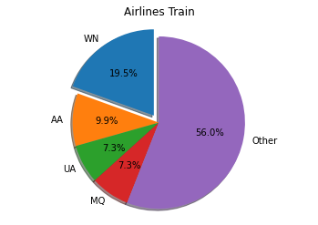

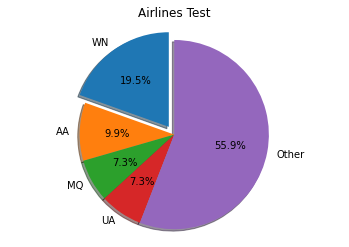

```python
## Pie chart of UniqueCarrier using Matplotlib

########
# Train
########
main_sizes = list(df_train["UniqueCarrier"].value_counts()[:4])
other_sizes = df_train["UniqueCarrier"].value_counts()[4:].sum()
main_sizes.append(other_sizes)

main_labels = list(df_train["UniqueCarrier"].value_counts().index[:4])
labels = main_labels.append("Other")

fig1, ax1 = plt.subplots()
plt.title("Airlines Train")

ax1.pie(main_sizes, labels = main_labels, explode = [0.1, 0, 0, 0, 0], autopct='%1.1f%%',
        shadow=True, startangle=90)
ax1.axis('equal')

plt.show;

########
# Test
########
main_sizes = list(df_test["UniqueCarrier"].value_counts()[:4])
other_sizes = df_test["UniqueCarrier"].value_counts()[4:].sum()
main_sizes.append(other_sizes)

main_labels = list(df_test["UniqueCarrier"].value_counts().index[:4])
labels = main_labels.append("Other")

fig2, ax2 = plt.subplots()
plt.title("Airlines Test")

ax2.pie(main_sizes, labels = main_labels, explode = [0.1, 0, 0, 0, 0], autopct='%1.1f%%',
        shadow=True, startangle=90)
ax2.axis('equal')

plt.show;
```

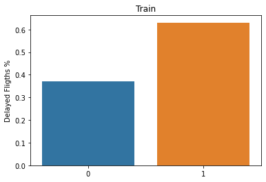

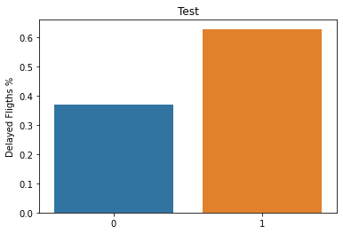

```python
## BarPlot with Seaborn
########
# Train
########
percentage = df_train["DelayCat"].value_counts()/df_train["DelayCat"].value_counts().sum()
ax1 = sns.barplot(x = df_train["DelayCat"].value_counts().index, y = percentage);
ax1.set_ylabel("Delayed Fligths %"); ax1.set_title("Train")
plt.show();


########
# Test
########
percentage = df_test["DelayCat"].value_counts()/df_test["DelayCat"].value_counts().sum()
ax2 = sns.barplot(x = df_test["DelayCat"].value_counts().index, y = percentage);
ax2.set_ylabel("Delayed Fligths %"); ax2.set_title("Test")
plt.show();
```

Aquestes dues gràfiques construides sobre els dos datasets son un exemple de com es manté la similitud després de subdividir el dataset original en conjunt de entranament i de testeig. Això es degut al gran tamany del dataset original.

# Exercici 2

```python
# Inicializar Scaler
Scaler = RobustScaler()

# Escalar Numeric Variables
df_train_num.loc[:,:] = Scaler.fit_transform(df_train_num.values)
df_test_num.loc[:,:] = Scaler.fit_transform(df_test_num.values)
```

El feature enginyering ja es va fer al Sprint 4 y les gràfiques son les exposades a l'exercici 1. En aquesta ocasió normalitzarem totes les variables numeriques i mostrarem las seves distribucións per comparar entre el conjunt d'entrenament i el conjunt de testeig.

# Exercici 3

```python
# Drop delay columns
df_train_num = df_train_num.drop(['CarrierDelay', 'WeatherDelay', 'NASDelay', 'SecurityDelay',
                                'LateAircraftDelay'], axis=1)
df_test_num = df_test_num.drop(['CarrierDelay', 'WeatherDelay', 'NASDelay', 'SecurityDelay',
                                'LateAircraftDelay'], axis=1)
```

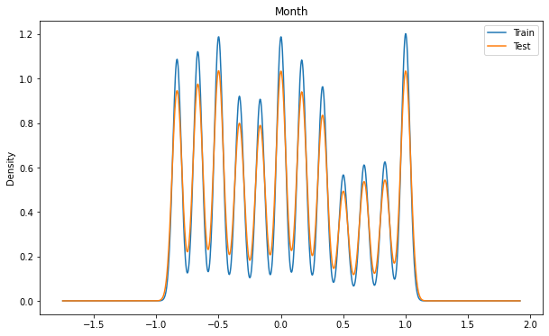

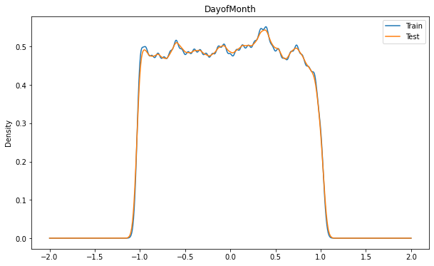

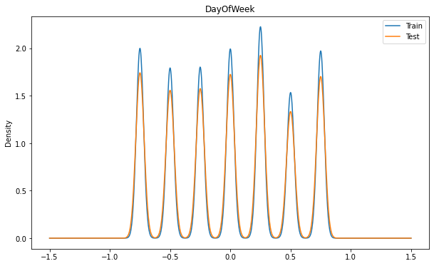

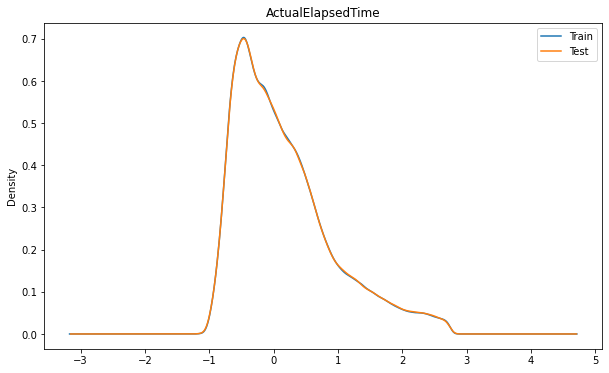

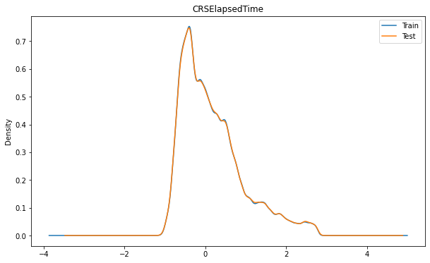

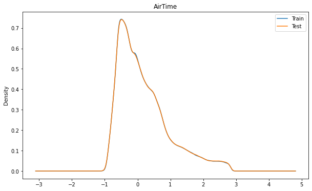

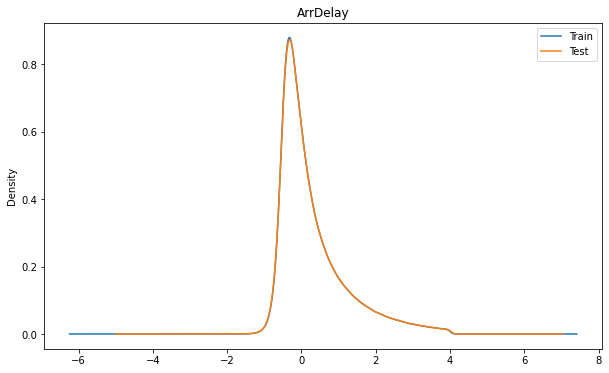

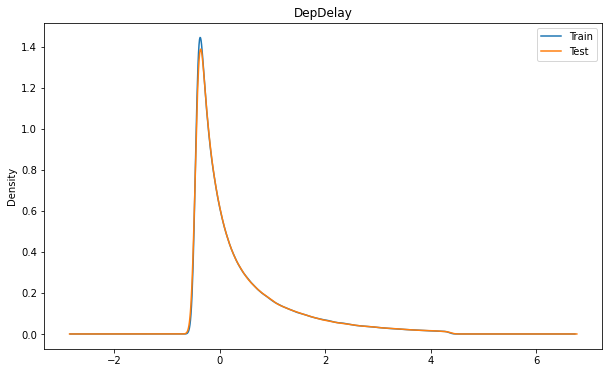

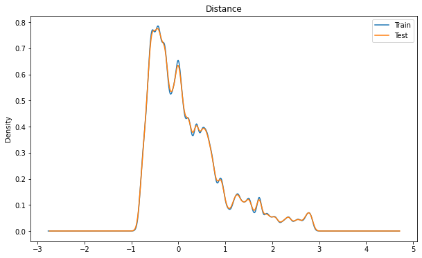

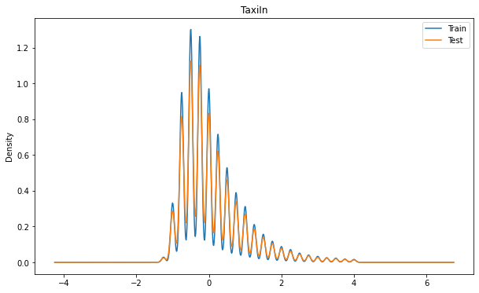

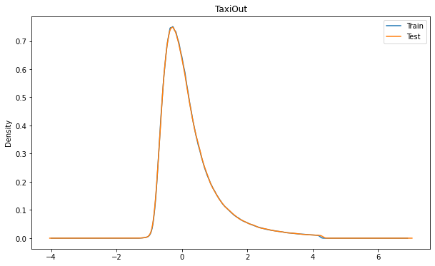

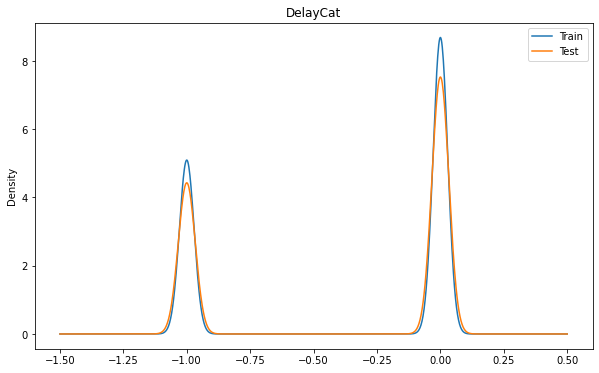

[1 more figures not shown]

```python
# Plots
for jj, ii in enumerate(df_train_num.columns):
    plt.figure(figsize=(10, 6))
    # Filter outliers
    filtered_entries = np.abs(stats.zscore(df_train_num[ii])) < 3
    df_train_num[filtered_entries][ii].plot.density()
    # Filter outliers
    filtered_entries = np.abs(stats.zscore(df_test_num[ii])) < 3
    df_test_num[filtered_entries][ii].plot.density()
    plt.title(ii)
    plt.legend(["Train", "Test"])
    plt.show()
```

La distribució de densitat de les diferents variables es mantenen pràcticament igual en els dos conjunts.